# Data Analyst Job Market Analysis

- Section 1: Introduction
- Section 2: Experience vs. Salary Relationship
- Section 3: Salary Distribution by Programming Language
- Section 4: AI Reflection

## Section 1: Introduction

This exercise uses data about jobs for Data Analysts. Using LLMs, it extracts information about the number of years of required experience and which data languages are needed. As part of the exercise, two graphs are generated.

## Section 2: Experience vs. Salary Relationship

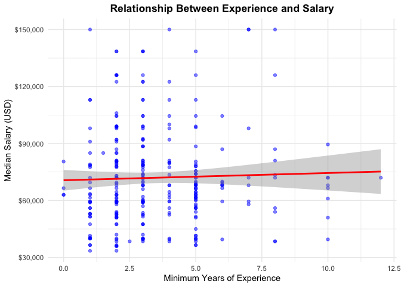

## Section 3: Salary Distribution by Programming Language

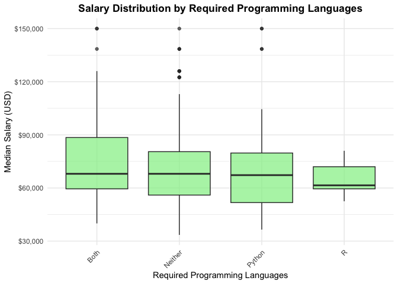

## Section 4: AI Reflection

I am surprised how easy it is to use AI to extract information from a dataset. I did run into a small problem with the prompt and it gave me an incorrect answer at the beginning. For relatively small datasets, it is possible to check that the AI has performed the task correctly by manual review. However, I am not sure how this could be done for very large datasets.